# Introduction to clustifyr

Rui Fu, Austin Gillen, Ryan Sheridan, Chengzhe Tian, Michelle Daya, Yue Hao, Jay Hesselberth and Kent Riemondy

raysinensis@gmail.com

2019-11-19

# 1 Introduction: Why use `clustifyr`?

Single cell transcriptomes are difficult to annotate without extensive knowledge of the underlying biology of the system in question. Even with this knowledge, accurate identification can be challenging due to the lack of detectable expression of common marker genes defined by bulk RNA-seq, flow cytometry, other single cell RNA-seq platforms, etc.

`clustifyr` solves this problem by providing functions to automatically annotate single cells or clusters using bulk RNA-seq data or marker gene lists (ranked or unranked). Additional functions allow for exploratory analysis of calculated similarities between single cell RNA-seq datasets and reference data.

# 2 Installation

To install `clustifyr` BiocManager must be installed.

```
install.packages("BiocManager")

BiocManager::install("clustifyr")
```

# 3 A simple example: 10x Genomics PBMCs

In this example, we take a 10x Genomics 3’ scRNA-seq dataset from peripheral blood mononuclear cells (PBMCs) and annotate the cell clusters (identified using `Seurat`) using scRNA-seq cell clusters assigned from a CITE-seq experiment.

```r
library(clustifyr)
library(ggplot2)
library(cowplot)

# Matrix of normalized single-cell RNA-seq counts
pbmc_matrix <- clustifyr::pbmc_matrix_small

# meta.data table containing cluster assignments for each cell
# The table that we are using also contains the known cell identities in the "classified" column
pbmc_meta <- clustifyr::pbmc_meta
```

## 3.1 Calculate correlation coefficients

To identify cell types, the `clustifyr()` function requires several inputs:

- `input`: a Seurat object or a matrix of normalized single-cell RNA-seq counts
- `metadata`: a meta.data table containing the cluster assignments for each cell (not required if a Seurat object is given)
- `ref_mat`: a reference matrix containing RNA-seq expression data for each cell type of interest
- `query_genes`: a list of genes to use for comparison (optional but recommended)

When using a matrix of scRNA-seq counts `clustifyr()` will return a matrix of correlation coefficients for each cell type and cluster, with the rownames corresponding to the cluster number.

```r
# Calculate correlation coefficients for each cluster (spearman by default)
vargenes <- pbmc_vargenes[1:500]

res <- clustify(
  input = pbmc_matrix, # matrix of normalized scRNA-seq counts (or a Seurat object)
  metadata = pbmc_meta, # meta.data table containing cell clusters
  cluster_col = "seurat_clusters", # name of column in meta.data containing cell clusters
  ref_mat = cbmc_ref, # matrix of RNA-seq expression data for each cell type
  query_genes = vargenes # list of highly varible genes identified with Seurat
)

# Peek at correlation matrix
res[1:5, 1:5]
```

```
#>           B CD14+ Mono CD16+ Mono     CD34+     CD4 T
#> 0 0.7345444  0.6571888  0.6704756 0.7426868 0.8930064
#> 1 0.7118115  0.6500660  0.6719955 0.7382099 0.8654573
#> 2 0.6159989  0.9140277  0.8629032 0.6354744 0.5810497
#> 3 0.8843411  0.6365743  0.6640880 0.7409892 0.7429827
#> 4 0.6654634  0.6043520  0.6332612 0.6843847 0.7814971
```

```r
# Call cell types
res2 <- cor_to_call(
  cor_mat = res,                  # matrix correlation coefficients
  cluster_col = "seurat_clusters" # name of column in meta.data containing cell clusters
)
res2[1:5, ]
```

```
#> # A tibble: 5 x 3
#> # Groups:   seurat_clusters [5]
#>   seurat_clusters type           r
#>   <chr>           <chr>      <dbl>
#> 1 3               B          0.884
#> 2 2               CD14+ Mono 0.914
#> 3 5               CD16+ Mono 0.910
#> 4 0               CD4 T      0.893
#> 5 1               CD4 T      0.865
```

```r
# Insert into original metadata as "type" column
pbmc_meta2 <- call_to_metadata(
  res = res2,                     # data.frame of called cell type for each cluster
  metadata = pbmc_meta,           # original meta.data table containing cell clusters
  cluster_col = "seurat_clusters" # name of column in meta.data containing cell clusters
)
```

To visualize the `clustifyr()` results we can use the `plot_cor_heatmap()` function to plot the correlation coefficients for each cluster and each cell type.

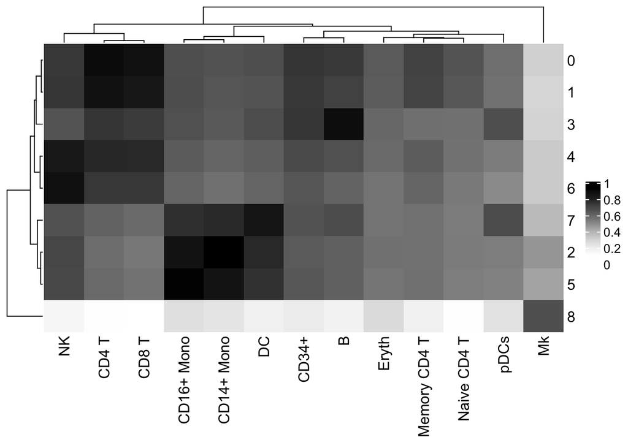

```r
# Create heatmap of correlation coefficients using clustifyr() output
plot_cor_heatmap(cor_mat = res)
```

## 3.2 Plot cluster identities and correlation coefficients

`clustifyr` also provides functions to overlay correlation coefficients on pre-calculated tSNE embeddings (or those from any other dimensionality reduction method).

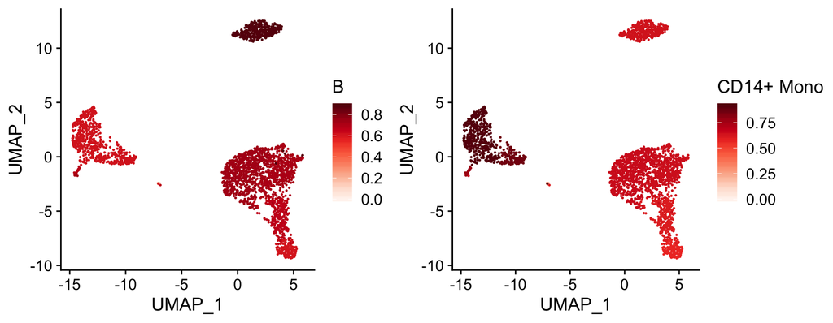

```r
# Overlay correlation coefficients on UMAPs for the first two cell types
corr_umaps <- plot_cor(
  cor_mat = res,                     # matrix of correlation coefficients from clustifyr()
  metadata = pbmc_meta,              # meta.data table containing UMAP or tSNE data
  data_to_plot = colnames(res)[1:2], # name of cell type(s) to plot correlation coefficients
  cluster_col = "seurat_clusters"    # name of column in meta.data containing cell clusters
)

plot_grid(
  plotlist = corr_umaps,
  rel_widths = c(0.47, 0.53)
)
```

The `plot_best_call()` function can be used to label each cluster with the cell type that gives the highest corelation coefficient. Using the `plot_dims()` function, we can also plot the known identities of each cluster, which were stored in the “classified” column of the meta.data table. The plots below show that the highest correlations between the reference RNA-seq data and the 10x Genomics scRNA-seq dataset are restricted to the correct cell clusters.

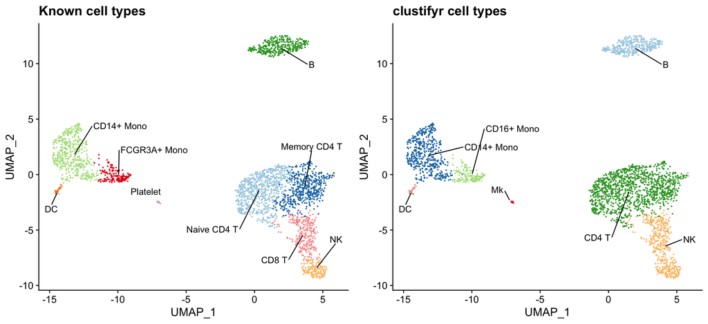

```r
# Label clusters with clustifyr cell identities
clustifyr_types <- plot_best_call(
  cor_mat = res,          # matrix of correlation coefficients from clustifyr()
  metadata = pbmc_meta,   # meta.data table containing UMAP or tSNE data
  do_label = TRUE,        # should the feature label be shown on each cluster?
  do_legend = FALSE,      # should the legend be shown?
  cluster_col = "seurat_clusters"
) +
  ggtitle("clustifyr cell types")

# Compare clustifyr results with known cell identities
known_types <- plot_dims(
  data = pbmc_meta,       # meta.data table containing UMAP or tSNE data
  feature = "classified", # name of column in meta.data to color clusters by
  do_label = TRUE,        # should the feature label be shown on each cluster?
  do_legend = FALSE       # should the legend be shown?
) +
  ggtitle("Known cell types")

plot_grid(known_types, clustifyr_types)
```

# 4 Classify cells using known marker genes

The `clustify_lists()` function allows cell types to be assigned based on known marker genes. This function requires a table containing markers for each cell type of interest. Cell types can be assigned using several statistical tests including, hypergeometric, Jaccard, Spearman, and GSEA.

```r
# Take a peek at marker gene table
cbmc_m
```

```
#>   CD4 T CD8 T Memory CD4 T CD14+ Mono Naive CD4 T   NK     B CD16+ Mono
#> 1 ITM2A  CD8B        ADCY2     S100A8       CDHR3 GNLY  IGHM     CDKN1C
#> 2 TXNIP  CD8A       PTGDR2     S100A9  DICER1-AS1 NKG7 CD79A       HES4
#> 3   AES S100B      CD200R1        LYZ       RAD9A CST7 MS4A1        CKB
#>      CD34+ Eryth    Mk    DC   pDCs
#> 1   SPINK2   HBM   PF4  ENHO LILRA4
#> 2  C1QTNF4  AHSP  SDPR  CD1E   TPM2
#> 3 KIAA0125   CA1 TUBB1 NDRG2    SCT
```

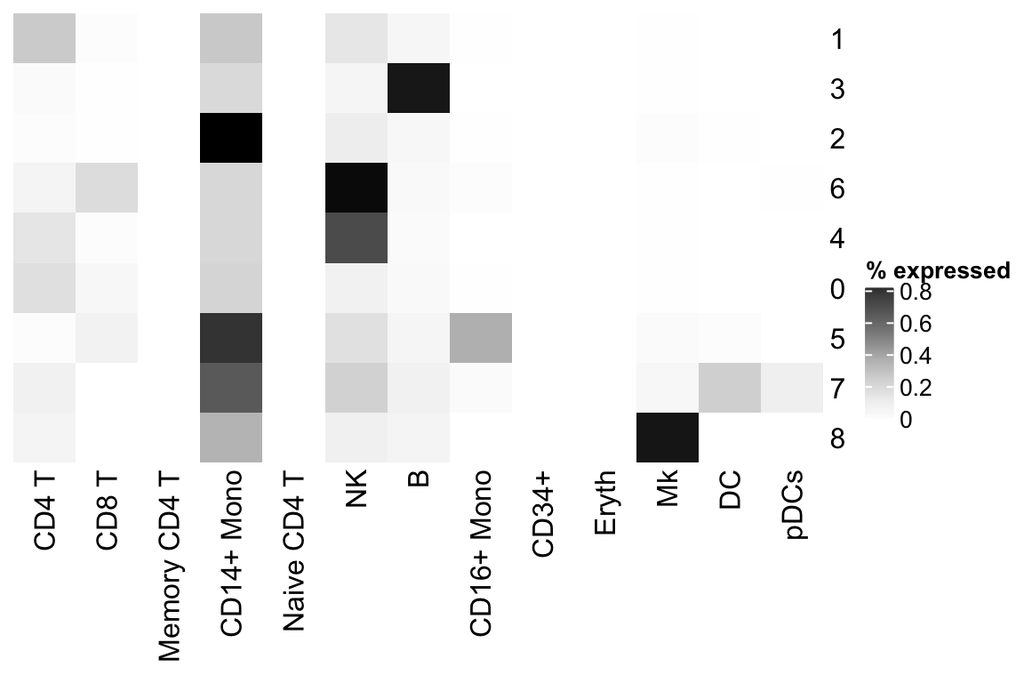

```r
# Available metrics include: "hyper", "jaccard", "spearman", "gsea"
list_res <- clustify_lists(
  input = pbmc_matrix,             # matrix of normalized single-cell RNA-seq counts
  metadata = pbmc_meta,            # meta.data table containing cell clusters
  cluster_col = "seurat_clusters", # name of column in meta.data containing cell clusters
  marker = cbmc_m,                 # list of known marker genes
  metric = "pct"                   # test to use for assigning cell types
)

# View as heatmap, or plot_best_call
plot_cor_heatmap(
  cor_mat = list_res,              # matrix of correlation coefficients from clustify_lists()
  cluster_rows = FALSE,            # cluster by row?
  cluster_columns = FALSE,         # cluster by column?
  legend_title = "% expressed"     # title of heatmap legend
)
```

```r
# Downstream functions same as clustify()
# Call cell types
list_res2 <- cor_to_call(
  cor_mat = list_res,              # matrix correlation coefficients
  cluster_col = "seurat_clusters"  # name of column in meta.data containing cell clusters
)

# Insert into original metadata as "list_type" column
pbmc_meta3 <- call_to_metadata(
  res = list_res2,                 # data.frame of called cell type for each cluster
  metadata = pbmc_meta,            # original meta.data table containing cell clusters
  cluster_col = "seurat_clusters", # name of column in meta.data containing cell clusters
  rename_prefix = "list_"          # set a prefix for the new column
)
```

# 5 Direct handling of `seurat` v2 and v3 objects

`clustifyr` can also use a `Seurat` object as input and return a new `Seurat` object with the cell types added as a column in the meta.data.

```r
library(Seurat)
res <- clustify(
  input = s_small,       # a Seurat object
  ref_mat = cbmc_ref,    # matrix of RNA-seq expression data for each cell type
  cluster_col = "res.1", # name of column in meta.data containing cell clusters
  seurat_out = TRUE      # output Seurat object with cell type inserted as "type" column
)

res@meta.data[1:10, ]
```

```
#>                nGene nUMI    orig.ident res.0.8 res.1         type         r
#> ATGCCAGAACGACT    47   70 SeuratProject       0     0 Memory CD4 T 0.7047302
#> CATGGCCTGTGCAT    52   85 SeuratProject       0     0 Memory CD4 T 0.7047302
#> GAACCTGATGAACC    50   87 SeuratProject       0     0 Memory CD4 T 0.7047302
#> TGACTGGATTCTCA    56  127 SeuratProject       0     0 Memory CD4 T 0.7047302
#> AGTCAGACTGCACA    53  173 SeuratProject       0     0 Memory CD4 T 0.7047302
#> TCTGATACACGTGT    48   70 SeuratProject       0     0 Memory CD4 T 0.7047302
#> TGGTATCTAAACAG    36   64 SeuratProject       0     0 Memory CD4 T 0.7047302
#> GCAGCTCTGTTTCT    45   72 SeuratProject       0     0 Memory CD4 T 0.7047302
#> GATATAACACGCAT    36   52 SeuratProject       0     0 Memory CD4 T 0.7047302
#> AATGTTGACAGTCA    41  100 SeuratProject       0     0 Memory CD4 T 0.7047302
```

# 6 Building reference matrix from single cell expression matrix

In its simplest form, a reference matrix is built by averaging expression (also includes an option to take the median) of a single cell RNA-seq expression matrix by cluster. Both log transformed or raw count matrices are supported.

```r
new_ref_matrix <- average_clusters(
  mat = pbmc_matrix,
  metadata = pbmc_meta$classified, # or use metadata = pbmc_meta, cluster_col = "classified"
  if_log = TRUE                    # whether the expression matrix is already log transformed
)

head(new_ref_matrix)
```

```
#>                 B CD14+ Mono      CD8 T         DC FCGR3A+ Mono Memory CD4 T
#> PPBP   0.09375021 0.28763857 0.35662599 0.06527347    0.2442300   0.06494743
#> LYZ    1.42699419 5.21550849 1.35146753 4.84714962    3.4034309   1.39466552
#> S100A9 0.62123058 4.91453355 0.58823794 2.53310734    2.6277996   0.58080250
#> IGLL5  2.44576997 0.02434753 0.03284986 0.10986617    0.2581198   0.04826212
#> GNLY   0.37877736 0.53592906 2.53161887 0.46959958    0.2903092   0.41001072
#> FTL    3.66698837 5.86217774 3.37056910 4.21848878    5.9518479   3.31062958
#>        Naive CD4 T         NK  Platelet
#> PPBP    0.04883837 0.00000000 6.0941782
#> LYZ     1.40165143 1.32701580 2.5303912
#> S100A9  0.55679700 0.52098541 1.6775692
#> IGLL5   0.03116080 0.05247669 0.2501642
#> GNLY    0.46041901 4.70481754 0.3845813
#> FTL     3.35611600 3.38471536 4.5508242
```

```r
# For further convenience, a shortcut function for generating reference matrix from  `seurat` object is used.
new_ref_matrix_v2 <- seurat_ref(
  seurat_object = s_small,         # seuratv2 object
  cluster_col = "res.1"            # name of column in meta.data containing cell identities
)

new_ref_matrix_v3 <- seurat_ref(
  seurat_object = s_small3,        # SeuratV3 object
  cluster_col = "RNA_snn_res.1"    # name of column in meta.data containing cell identities
)

tail(new_ref_matrix_v3)
```

```
#>                 0         1        2
#> C12orf75 3.223784 0.4297757 2.305767
#> RARRES3  4.341699 1.7550597 3.794566
#> PCMT1    4.576310 2.8893691 2.223141
#> LAMP1    3.919129 0.9441022 1.565788
#> SPON2    3.670497 1.3182933 3.200796
#> S100B    3.069210 0.0000000 0.000000
```

More reference data, including tabula muris, and code used to generate them are available at https://github.com/rnabioco/clustifyrdata.

Also see list for individual downloads at https://rnabioco.github.io/clustifyr/articles/download_refs.html